# Tree Species Codings in ForestElementsR

Peter Biber

## 1. Introduction

Unfortunately, the way how tree species are coded in forest data varies vastly among research institutions, forest administrations, and the likes. In order to make the package *ForestElementsR* broadly applicable, it requires a generic coding system that can cover any specific species coding system and allows to translate from one into the other. In contrast to what one might expect, this is not a trivial task, as most existing codings do include not only codes for single species, but also for species groups. These groups are rarely the same across different codings which causes certain issues to be covered by a useful generic coding system. Such a generic approach, in addition, requires to be open to include any desired additional species and specific codings.

## 2. Where to find things and what they are good for

Before I show how to actually work with species codings in *ForestElementsR*, I will talk about where to find all implemented codings in the package. For the code examples below to work, you will need to attach *ForestElementsR* itself, and the packages *tibble*, *dplyr*, and *ggplot2* from the [*tidyverse*](https://tidyverse.org/) which make handling and output more convenient.

```r
library(ForestElementsR)
library(tibble)
library(dplyr)
library(ggplot2)
```

### 2.1 The species master table

The *data.frame* (actually a *tibble*) *species_master_table* is the most important part of the generic species coding system. Any single species to be included in any specific coding must be absolutely listed here, as the species master table serves as the common reference for all implemented codings. Conversely, specific species codings do not need to comprise all species provided in the species master table. In order to view this table, it is only necessary to type its name:

```r
species_master_table
```

```
#> # A tibble: 101 × 6
#>    genus species_no deciduous_conifer name_sci               name_eng   name_ger
#>    <chr> <chr>      <chr>             <chr>                  <chr>      <chr>
#>  1 abies 001        conif             Abies alba             silver fir Tanne
#>  2 abies 002        conif             Abies grandis          Oregon fir Große K…
#>  3 abies 003        conif             Abies balsamea         balsam fir Balsamt…
#>  4 abies 004        conif             Abies concolor         white fir  Kolorad…
#>  5 abies 005        conif             Abies concolor lowiana Sierra wh… Sierra-…
#>  6 abies 006        conif             Abies amabilis         red fir    Purpurt…
#>  7 abies 007        conif             Abies firma            Momi fir   Momi-Ta…
#>  8 abies 008        conif             Abies homolepis        Nikko fir  Nikko-T…
#>  9 abies 009        conif             Abies nordmanniana     Nordmann … Nordman…
#> 10 abies 010        conif             Abies procera          noble fir  Edeltan…
#> # ℹ 91 more rows
```

```r
# Also show the tail of the table
species_master_table |> tail(10)
```

```
#> # A tibble: 10 × 6
#>    genus  species_no deciduous_conifer name_sci           name_eng      name_ger
#>    <chr>  <chr>      <chr>             <chr>              <chr>         <chr>
#>  1 sorbus 001        decid             Sorbus aucuparia   rowan         Vogelbe…
#>  2 sorbus 002        decid             Sorbus torminalis  wild service… Elsbeere
#>  3 sorbus 003        decid             Sorbus aria        common white… Mehlbee…
#>  4 sorbus 004        decid             Sorbus intermedia  Swedish whit… Schwedi…
#>  5 sorbus 005        decid             Sorbus domestica   sorb tree     Speierl…
#>  6 tilia  001        decid             Tilia cordata      small-leaved… Winterl…
#>  7 tilia  002        decid             Tilia platyphyllos large-leaved… Sommerl…
#>  8 ulmus  001        decid             Ulmus glabra       Scots elm     Bergulme
#>  9 ulmus  002        decid             Ulmus minor        field elm     Feldulme
#> 10 ulmus  003        decid             Ulmus laevis       European whi… Flatter…
```

In contrast to specific codings (see below) the species master table must contain single species only, i.e. each row represents a species, never a group of species. Currently, it comprises 101 tree species. Let us have a look at the table’s anatomy:

The key fields of the species master table are *genus* and *species_no*. Together, they must be unique. Both are of type character. *genus* represents a specie’s genus name, *always in lower case letters*, and *species_no* is always a three-digit number with leading zeroes. This approach was chosen because of a few advantages: While genus names are usually stable, species names may change more often. Therefore, the species inside a genus are identified with a number instead of a name. New species can be easily added without the danger of running out of numbers and being thus forced to break the coding concept. For convenience, the table also contains the column *deciduous_conifer* which allows only for the two values *conif* and *decid*. This column is not part of the actual species key, but it is intended for filtering purposes, and for all relevant forest tree species, the distinction between both groups should be biologically correct or at least practical. The three remaining fields, *name_sci*, *name_eng*, and *name_ger* contain the scientific, colloquial English, and colloquial German names of all species.

### 2.2 Specific species codings

#### 2.2.1 General setup

All specific species codings implemented in *ForestElementsR* are stored in the tibble *species_codings*:

```r
species_codings
```

```
#> # A tibble: 6 × 2
#>   species_coding    code_table
#>   <chr>             <named list>
#> 1 master            <tibble [101 × 9]>
#> 2 tum_wwk_short     <tibble [101 × 9]>
#> 3 tum_wwk_long      <tibble [144 × 9]>
#> 4 ger_nfi_2012      <tibble [101 × 9]>
#> 5 bavrn_state       <tibble [137 × 9]>
#> 6 bavrn_state_short <tibble [101 × 9]>
```

Each row in this tibble represents a specific coding; hereby the column `species_coding` provides the coding’s name, and the column `code_table` provides an own tibble that defines the coding and links it to the species master table. Currently, there are six codings implemented (*master*, *tum_wwk_short*, *tum_wwk_long*, *ger_nfi_2012*, *bavrn_state*, *bavrn_state_short*). We use the coding *tum_wwk_short* for explaining the implementation. This species coding is used for many purposes at the Chair of Forest Growth and Yield Science at the Technical University of Munich. It comprises a small set of the most important tree species in Central Europe only, while all other species are attributed to three larger container groups. In order to see the coding table, it could be accessed by usual indexing of the tibble *species_coding*, but it is more convenient to use the function *fe_species_get_coding_table* which needs to be called with the name of the desired coding:

```r
fe_species_get_coding_table("tum_wwk_short")
```

```
#> # A tibble: 101 × 9
#>    species_id genus      species_no deciduous_conifer name_sci name_eng name_ger
#>    <chr>      <chr>      <chr>      <chr>             <chr>    <chr>    <chr>
#>  1 1          picea      001        conif             Picea a… Norway … Fichte
#>  2 2          abies      001        conif             Abies a… silver … Tanne
#>  3 3          pinus      001        conif             Pinus s… Scots p… Kiefer
#>  4 4          larix      001        conif             Larix d… Europea… Europäi…
#>  5 5          fagus      001        decid             Fagus s… Europea… Buche
#>  6 6          quercus    001        decid             Quercus… peduncu… Eiche (…
#>  7 6          quercus    002        decid             Quercus… peduncu… Eiche (…
#>  8 7          pseudotsu… 001        conif             Pseudot… Douglas… Douglas…
#>  9 8          acer       001        decid             aliae d… other h… Sonstig…
#> 10 8          acer       002        decid             aliae d… other h… Sonstig…
#> # ℹ 91 more rows
#> # ℹ 2 more variables: level <int>, is_tree <lgl>
```

Clearly, this table closely resembles the species master table, as they have in common the columns *genus*, *species_no*, *deciduous_conifer*, *name_sci*, *name_eng*, and *name_ger*. Most importantly, however, there is the additional column *species_id*. This column contains the actual coding, and it is always of type character, even if the coding is exclusively consisting of numbers. Such a coding table is not required to comprise all species available in the species master table, but it must not contain any species which is not included there. In other words, a coding table is not allowed to contain any combination of *genus* and *species_no* which is not contained in the species master table. The species names, however, may differ from those in the master table in order to allow e.g. for regional colloquial naming preferences or, more importantly, for naming species groups which, by definition, do not exist in the master table.

Besides *species_id*, every coding table carries two more columns, *level* and *is_tree*. The column *level* marks how fine or coarse a code is: *0* is the finest level (a single species, or a group that is not contained in any other group of the coding), and higher numbers denote ever coarser groups that nest the finer ones. For a “flat” coding that only distinguishes single species and non-overlapping groups, *level* is *0* throughout. Codings that additionally provide nesting group codes are called *hierarchical*; they are explained in Section 2.2.2. The column *is_tree* is *TRUE* for all ordinary tree-species codes and *FALSE* for the rare codes that denote a non-tree category such as a shrub; see Section 2.2.3.

Let us have a view on the coding in compact form:

```r
fe_species_get_coding_table("tum_wwk_short") |>
  select(species_id, name_eng) |> # English names only for clarity
  distinct()
```

```
#> # A tibble: 10 × 2
#>    species_id name_eng
#>    <chr>      <chr>
#>  1 1          Norway spruce
#>  2 2          silver fir
#>  3 3          Scots pine
#>  4 4          European larch
#>  5 5          European beech
#>  6 6          pedunculate/sessile oak (group)
#>  7 7          Douglas fir
#>  8 8          other hardwood
#>  9 9          soft deciduous wood
#> 10 10         other conifers
```

As it is easily visible in this display, the coding distinguishes only ten species (groups). From the names, it can be already guessed which species_ids refer to single species and which to groups, but we should use R to find this out unambiguously:

```r
fe_species_get_coding_table("tum_wwk_short") |>
  group_by(species_id, name_eng) |>
  summarise(n_species = n()) |>
  arrange(as.numeric(species_id)) # not required, but output is nicely sorted
```

```
#> `summarise()` has regrouped the output.
#> ℹ Summaries were computed grouped by species_id and name_eng.
#> ℹ Output is grouped by species_id.
#> ℹ Use `summarise(.groups = "drop_last")` to silence this message.
#> ℹ Use `summarise(.by = c(species_id, name_eng))` for per-operation grouping
#>   (`?dplyr::dplyr_by`) instead.
#> # A tibble: 10 × 3
#> # Groups:   species_id [10]
#>    species_id name_eng                        n_species
#>    <chr>      <chr>                               <int>
#>  1 1          Norway spruce                           1
#>  2 2          silver fir                              1
#>  3 3          Scots pine                              1
#>  4 4          European larch                          1
#>  5 5          European beech                          1
#>  6 6          pedunculate/sessile oak (group)         2
#>  7 7          Douglas fir                             1
#>  8 8          other hardwood                         43
#>  9 9          soft deciduous wood                    10
#> 10 10         other conifers                         40
```

Clearly, every species_id with n_species > 1 actually represents a group of tree species. Let us look at the smallest group (species_id 6), which comprises only two species:

```r
fe_species_get_coding_table("tum_wwk_short") |>
  select(species_id, genus, species_no, name_eng) |>
  filter(species_id == "6")
```

```
#> # A tibble: 2 × 4
#>   species_id genus   species_no name_eng
#>   <chr>      <chr>   <chr>      <chr>
#> 1 6          quercus 001        pedunculate/sessile oak (group)
#> 2 6          quercus 002        pedunculate/sessile oak (group)
```

We see that the two species in this group are *quercus* *001* and *quercus* *002*, but the colloquial species name in the coding table is the group name only. In order to find out the species names, we can obtain them from the species master table with the help of *genus* and *species_no*:

```r
species_master_table |>
  filter(genus == "quercus" & species_no %in% c("001", "002")) |>
  select(-deciduous_conifer)
```

```
#> # A tibble: 2 × 5
#>   genus   species_no name_sci        name_eng        name_ger
#>   <chr>   <chr>      <chr>           <chr>           <chr>
#> 1 quercus 001        Quercus robur   pedunculate oak Stieleiche
#> 2 quercus 002        Quercus petraea sessile oak     Traubeneiche
```

#### 2.2.2 Species groups and hierarchical codings

Almost every real-world coding distinguishes not only single species but also *species groups*. In the simplest case, a coding is a *partition*: each species belongs to exactly one code, and the codes never overlap. The *tum_wwk_short* coding used above is such a partition - the group codes 8, 9, and 10 are disjoint, and so are the single-species codes.

Some codings, however, need a species to appear **both** as its own code **and** inside a coarser group of the *same* coding. The Bavarian state coding *bavrn_state*, for instance, codes the pedunculate oak singly as *54* and the sessile oak singly as *55*, but it also keeps the older group code *70* (“oak”) that comprises both. Such codings are called *hierarchical*. To keep casting between codings well defined, the codes of a coding must form a *laminar family*: the species sets of any two codes are either disjoint or fully nested - partial overlaps are forbidden. The column *level* records the nesting depth (0 = finest leaf, higher = coarser group).

We can see this directly in the coding table of *bavrn_state*. The leaf codes 54 and 55 sit at level 0, while the group code 70 that contains them sits at level 1:

```r
fe_species_get_coding_table("bavrn_state") |>
  filter(species_id %in% c("54", "55", "70")) |>
  select(species_id, genus, species_no, name_eng, level)
```

```
#> # A tibble: 6 × 5
#>   species_id genus   species_no name_eng        level
#>   <chr>      <chr>   <chr>      <chr>           <int>
#> 1 54         quercus 001        pedunculate oak     0
#> 2 55         quercus 002        sessile oak         0
#> 3 70         quercus 001        oak (group)         1
#> 4 70         quercus 002        oak (group)         1
#> 5 70         quercus 003        oak (group)         1
#> 6 70         quercus 006        oak (group)         1
```

When a species is *cast into* a hierarchical coding, it is always resolved to the **finest** code that represents it. The pedunculate oak (*quercus_001* in the master coding) therefore becomes the leaf code 54, not the group code 70:

```r
as_fe_species_bavrn_state(fe_species_master("quercus_001")) |> unclass()
```

```
#> [1] "54"
```

#### 2.2.3 Non-tree codes

A few codings contain legal codes that do not stand for a tree species and that one cannot compute with - for example the *bavrn_state* code *99* (“Strauch”, shrub). Such codes are flagged with *is_tree = FALSE* in the coding table. Whether a code is a tree code is *derived* from its link to the species master table (a code that resolves to at least one master species is a tree code), so there is no separate flag that could fall out of sync.

Two exported helpers report this information. `fe_species_non_tree_codes()` lists the non-tree codes of a coding, and `fe_species_is_tree()` tests, element by element, whether the codes of an **fe_species** vector denote tree species:

```r
fe_species_non_tree_codes("bavrn_state")
```

```
#> [1] "99"
```

```r
spec_ids <- fe_species_bavrn_state(c("10", "60", "99"))
fe_species_is_tree(spec_ids)
```

```
#> [1]  TRUE  TRUE FALSE
```

Constructing a species vector that contains a non-tree code is allowed (the code is part of the coding), but objects that are meant to hold computable trees - such as `fe_stand()` and its relatives - reject them with a clear error. When a non-tree code is *cast* into another coding, it resolves to `NA` (with a message), because it has no tree-species equivalent.

#### 2.2.4 Implemented codings

Six species codings are currently implemented. While their documentation is available in the package, and can be accessed with `?species_codings`, I list them also here:

- **master:** This is the original species coding used by the package *ForestElementsR*. It contains each species from the *species_master_table* and no species groups. This coding corresponds directly to the species_master_table. Its species_ids are the master table’s columns *genus* and *species_no* combined into one character string, separated by an underscore.
- **tum_wwk_short:** This is one of two codings in use at the Chair of Forest Growth and Yield Science at the Technical University of Munich. It defines only a small set of single species explicitly (the most important ones in Central Europe), while all other species are attributed to a few large container groups.
- **tum_wwk_long:** This is one of two codings in use at the Chair of Forest Growth and Yield Science at the Technical University of Munich. It defines a larger set of single species than the *tum_wwk_short* coding. This coding is *hierarchical* (see Section 2.2.2): besides the single-species (leaf) codes it also provides the coarser species-group codes that contain them, and it covers every species of the master table.
- **bavrn_state:** This species coding is the coding used by the Bavarian State Forest Service. It is *hierarchical* (e.g. the single oak codes 54 and 55 nest in the group code 70), and it contains one non-tree code (99, “Strauch”/shrub; see Section 2.2.3).
- **bavrn_state_short:** This coding combines the species of *bavrn_state* into larger groups. These groups are typically used by the Bavarian State Forest Service in aggregated evaluations.
- **ger_nfi_2012:** The ger_nfi_2012 species coding is the species coding used by the German National Forest Inventory of 2012 (Riedel et al. 2017).

#### 2.2.5 A field-ready coding table

The full coding table returned by `fe_species_get_coding_table()` carries *one row per elementary species*. For a hierarchical coding this means a species can occur several times (once as a leaf code and once in each group that contains it), and a group code spreads over as many rows as it has member species. That is exactly what the casting machinery needs, but it is awkward as a printed lookup key for field work.

For that purpose there is `fe_species_get_field_table()`. It returns the *code-level* view: **each code exactly once**, together with the name of the species or group it stands for. The names are taken from the coding itself (not from the master table), so group names appear as such, and all three name columns are always included regardless of the `fe_spec_lang` option. The rows are in the coding’s canonical order (leaf codes first, then the coarser groups), and the *level* and *is_tree* columns are kept, as both matter in the field:

```r
fe_species_get_field_table("tum_wwk_short")
```

```
#> # A tibble: 10 × 6
#>    species_id name_sci                   name_eng         name_ger level is_tree
#>    <chr>      <chr>                      <chr>            <chr>    <int> <lgl>
#>  1 1          Picea abies                Norway spruce    Fichte       0 TRUE
#>  2 2          Abies alba                 silver fir       Tanne        0 TRUE
#>  3 3          Pinus sylvestris           Scots pine       Kiefer       0 TRUE
#>  4 4          Larix decidua              European larch   Europäi…     0 TRUE
#>  5 5          Fagus sylvatica            European beech   Buche        0 TRUE
#>  6 6          Quercus robur/petraea      pedunculate/ses… Eiche (…     0 TRUE
#>  7 7          Pseudotsuga menziesii      Douglas fir      Douglas…     0 TRUE
#>  8 8          aliae deciduae             other hardwood   Sonstig…     0 TRUE
#>  9 9          aliae deciduae molli ligno soft deciduous … Weichla…     0 TRUE
#> 10 10         alia conifera              other conifers   Sonstig…     0 TRUE
```

Rendering such a table into a nicely formatted, printable document (e.g. a PDF) is deliberately left to the downstream packages that already carry a document-rendering toolchain; *ForestElementsR* itself only provides the data.

## 3. Usage

Species codes as implemented in this package are vectors with a few special properties. Most users of the package, will work with species codes as columns in a *data.frame* (or *tibble*), where they are provided in parallel with other columns (i.e. vectors) that contain other tree information, e.g. tree diameters, heights, or spatial coordinates. For the sake of clarity, however, we demonstrate most applications for isolated vectors of species codes.

### 3.1 Creating a species code vector

For each implemented species coding there exists a user friendly function for constructing a vector of species. The naming convention for this function is *fe_species_coding_name*, whereby *coding_name* is the name of the desired coding as in the column *species_coding* in the tibble *species_codings* (see above). Thus, e.g. for creating a vector of *tum_wwk_short* or *ger_nfi_2012* codes, one would use the functions *fe_species_tum_wwk_short* or *fe_species_ger_nfi_2012*, respectively. As their input, these functions require a vector of codes either in numeric or character format:

```r
spec_ids_1 <- fe_species_tum_wwk_short(c(1, 1, 1, 5, 5, 5, 5, 3, 3, 8, 9, 8))
spec_ids_2 <- fe_species_ger_nfi_2012(
  c(10, 10, 10, 100, 100, 100, 100, 20, 20, 190, 290, 190)
)

spec_ids_1
```

```
#> <fe_species_tum_wwk_short[12]>
#>  [1] 1 1 1 5 5 5 5 3 3 8 9 8
```

```r
spec_ids_2
```

```
#> <fe_species_ger_nfi_2012[12]>
#>  [1] 10  10  10  100 100 100 100 20  20  190 290 190
```

If the input vector contains codes which are not supported by the chosen coding, the attempt terminates with an error:

```r
fe_species_tum_wwk_short(c(1, 321, 1, 9999))
```

```
#> Error:
#> ! Code(s) 321, 9999 is/are not supported by species coding 'tum_wwk_short'
```

```r
fe_species_ger_nfi_2012(c("100", "290", "Peter", "Paul", "Mary"))
```

```
#> Error:
#> ! Code(s) Peter, Paul, Mary is/are not supported by species coding 'ger_nfi_2012'
```

For each implemented coding there exists a function *is_fe_species_coding_name* for checking whether an object is a vector of species codes of the requested class:

```r
spec_ids <- c(1:10)
is_fe_species_tum_wwk_short(spec_ids)
```

```
#> [1] FALSE
```

```r
spec_ids <- fe_species_tum_wwk_short(c(1:10))
is_fe_species_tum_wwk_short(spec_ids)
```

```
#> [1] TRUE
```

```r
is_fe_species_bavrn_state(spec_ids)
```

```
#> [1] FALSE
```

NA values are in principle allowed in species code vectors. There may be, however, objects (like *fe_stand*, covered in an own vignette) which enforce species code vectors without NAs.

### 3.2 Display options

By default, species code vectors are displayed “as they are”, i.e. what we see are the original codes as in the column *species_id* in the corresponding coding’s table (see above). Sometimes, e.g. for creating output for third parties, the actual species names are preferable. The most convenient way to achieve that is to set the option *fe_spec_lang* which can take the values *sci*, *eng*, *ger*, and *code*. Let’s create four species code vectors

```r
spec_ids_1 <- fe_species_tum_wwk_short(c(1, 1, 5, 5, 5, 5, 3, 3))
spec_ids_2 <- fe_species_ger_nfi_2012(c(100, 100, 20, 20, 30, 110))
spec_ids_3 <- fe_species_bavrn_state(c(60, 60, 30, 30, 84, 86))
spec_ids_4 <- fe_species_master(c("abies_001", "tilia_002", "ulmus_001"))
```

The default display is:

```
#> <fe_species_tum_wwk_short[8]>
#> [1] 1 1 5 5 5 5 3 3
#> <fe_species_ger_nfi_2012[6]>
#> [1] 100 100 20  20  30  110
#> <fe_species_bavrn_state[6]>
#> [1] 60 60 30 30 84 86
#> <fe_species_master[3]>
#> [1] abies_001 tilia_002 ulmus_001
```

With the option *fe_spec_lang* set on “sci”, the scientific species names are displayed:

```r
options(fe_spec_lang = "sci") # Display scientific species names

spec_ids_1
```

```
#> <fe_species_tum_wwk_short[8]>
#> [1] Picea abies      Picea abies      Fagus sylvatica  Fagus sylvatica
#> [5] Fagus sylvatica  Fagus sylvatica  Pinus sylvestris Pinus sylvestris
```

```r
spec_ids_2
```

```
#> <fe_species_ger_nfi_2012[6]>
#> [1] Fagus sylvatica  Fagus sylvatica  Pinus sylvestris Pinus sylvestris
#> [5] Abies alba       Quercus robur
```

```r
spec_ids_3
```

```
#> <fe_species_bavrn_state[6]>
#> [1] Fagus sylvatica Fagus sylvatica Abies alba      Abies alba
#> [5] Salix spec.     Alnus glutinosa
```

```r
spec_ids_4
```

```
#> <fe_species_master[3]>
#> [1] Abies alba         Tilia platyphyllos Ulmus glabra
```

For printing the colloquial English species names, the option “eng” is the choice:

```r
options(fe_spec_lang = "eng") # Display English species names

spec_ids_1
```

```
#> <fe_species_tum_wwk_short[8]>
#> [1] Norway spruce  Norway spruce  European beech European beech European beech
#> [6] European beech Scots pine     Scots pine
```

```r
spec_ids_2
```

```
#> <fe_species_ger_nfi_2012[6]>
#> [1] European beech  European beech  Scots pine      Scots pine
#> [5] silver fir      pedunculate oak
```

```r
spec_ids_3
```

```
#> <fe_species_bavrn_state[6]>
#> [1] European beech European beech silver fir     silver fir     willow (group)
#> [6] Black alder
```

```r
spec_ids_4
```

```
#> <fe_species_master[3]>
#> [1] silver fir        large-leaved lime Scots elm
```

```r
format(spec_ids_1, spec_lang = "eng")
```

```
#> [1] "Norway spruce"  "Norway spruce"  "European beech" "European beech"
#> [5] "European beech" "European beech" "Scots pine"     "Scots pine"
```

```r
format(spec_ids_2, spec_lang = "sci")
```

```
#> [1] "Fagus sylvatica"  "Fagus sylvatica"  "Pinus sylvestris" "Pinus sylvestris"
#> [5] "Abies alba"       "Quercus robur"
```

```r
format(spec_ids_3, spec_lang = "code")
```

```
#> [1] "60" "60" "30" "30" "84" "86"
```

```r
format(spec_ids_4, spec_lang = "ger")
```

```
#> [1] "Tanne"       "Sommerlinde" "Bergulme"
```

Note that the names for display are always taken from the specific coding’s table, not from the species master table. Be also aware that such species names are not the codes themselves. This means, you cannot generate a species code vector from a vector of species names:

```r
spec_names <- c("Abies alba", "Picea abies")
fe_species_ger_nfi_2012(spec_names)
```

```
#> Error:
#> ! Code(s) Abies alba, Picea abies is/are not supported by species coding 'ger_nfi_2012'
```

When assigning new values to elements of a species coding vector, the safest way to do so is to provide the new values as an instance of the same class. But with all other values, an attempt will be made to convert them into an instance of the goal class. If this is not possible, the assignment does not take place, and an error is thrown.

```r
spec_vec <- fe_species_bavrn_state(c("10", "10", "10", "50", "50", "50"))
format(spec_vec, "eng")
```

```
#> [1] "Norway spruce" "Norway spruce" "Norway spruce" "Douglas fir"
#> [5] "Douglas fir"   "Douglas fir"
```

```r
# Safest way, same class on both sides of the '<-'
spec_vec[3] <- fe_species_bavrn_state("40")
is_fe_species_bavrn_state(spec_vec)
```

```
#> [1] TRUE
```

```r
format(spec_vec, "eng")
```

```
#> [1] "Norway spruce"  "Norway spruce"  "European larch" "Douglas fir"
#> [5] "Douglas fir"    "Douglas fir"
```

```r
# Character vector is converted
spec_vec[3:4] <- c("40", "70")
is_fe_species_bavrn_state(spec_vec)
```

```
#> [1] TRUE
```

```r
format(spec_vec, "eng")
```

```
#> [1] "Norway spruce"  "Norway spruce"  "European larch" "oak (group)"
#> [5] "Douglas fir"    "Douglas fir"
```

```r
# Numerical vector is converted
spec_vec[3:4] <- c(60, 87)
is_fe_species_bavrn_state(spec_vec)
```

```
#> [1] TRUE
```

```r
format(spec_vec, "eng")
```

```
#> [1] "Norway spruce"  "Norway spruce"  "European beech" "noble hardwood"
#> [5] "Douglas fir"    "Douglas fir"
```

```r
# Species code not supported by goal coding - no assignment and error
spec_vec[1:2] <- c("3333", "12")
```

```
#> Error:
#> ! Code(s) 3333 is/are not supported by species coding 'bavrn_state'
```

```r
is_fe_species_bavrn_state(spec_vec)
```

```
#> [1] TRUE
```

```r
format(spec_vec, "eng")
```

```
#> [1] "Norway spruce"  "Norway spruce"  "European beech" "noble hardwood"
#> [5] "Douglas fir"    "Douglas fir"
```

```r
# Vectors of other species codings are converted, if possible
spec_vec[5:6] <- fe_species_tum_wwk_short(c("3", "3")) # "3" Scots pine in rhs
# coding
is_fe_species_bavrn_state(spec_vec)
```

```
#> [1] TRUE
```

```r
format(spec_vec, "code") # "3" becomes "20" ...
```

```
#> [1] "10" "10" "60" "87" "20" "20"
```

```r
format(spec_vec, "eng") # ... which is Scots pine in the goal coding
```

```
#> [1] "Norway spruce"  "Norway spruce"  "European beech" "noble hardwood"
#> [5] "Scots pine"     "Scots pine"
```

### 3.3 Species code conversions

For each implemented species coding there is a function *as_fe_species_coding_name* which tries to convert an object of any other given species coding implemented in *ForestElementsR* into an instance of the goal object. You can use it also for converting numeric or character vectors (as an alternative to *fe_species_coding_name*), but the interesting feature is the conversion between different codings:

```r
spec_ids <- as_fe_species_tum_wwk_short(c("1", "3", "5"))
as_fe_species_ger_nfi_2012(spec_ids) |> format("eng")
```

```
#> [1] "Norway spruce"  "Scots pine"     "European beech"
```

When the initial species code vector contains codes which belong to the same species group in the goal coding, information is lost when doing the conversion. This is a *backward ambiguous cast*. In such a case, the conversion is executed, but a *message* is issued. (In earlier versions of the package this was a *warning*; it was downgraded to a message because such information loss is the normal, intended outcome of aggregating into coarser groups, and a warning forced users to wrap every deliberate aggregation in `suppressWarnings()`.)

```r
spec_ids_1 <- as_fe_species_ger_nfi_2012(c("170", "150", "140"))
spec_ids_1 |> format("eng")
```

```
#> [1] "elm (spec.)"    "lime (spec.)"   "sycamore maple"
```

```r
# Backward ambiguous cast (possibly, but with information loss)
spec_ids_2 <- as_fe_species_tum_wwk_short(spec_ids_1)
```

```
#> Cast loses information. Goal code(s) 8 correspond to 3 original code(s).
```

```r
spec_ids_2 |> format("eng")
```

```
#> [1] "other hardwood" "other hardwood" "other hardwood"
```

Conversely, when casting *into* a hierarchical coding (one that offers both single-species and group codes, see Section 2.2.2), each species is resolved to the *finest* code available for it - the single-species code if there is one, the smallest containing group otherwise. This happens automatically and without information loss:

```r
# Pedunculate and sessile oak resolve to the single codes 54 and 55,
# not to the group code 70
as_fe_species_bavrn_state(fe_species_master(c("quercus_001", "quercus_002"))) |>
  format("code")
```

```
#> [1] "54" "55"
```

Conversions with no match in the goal coding terminate with an error:

```r
spec_ids <- as_fe_species_bavrn_state(c("11", "11", "11"))
spec_ids |> format("eng")
```

```
#> [1] "Serbian spruce" "Serbian spruce" "Serbian spruce"
```

```r
# No Serbian spruce in the tum_wwk_long coding
spec_ids |> as_fe_species_tum_wwk_long()
```

[output not shown]

*Forward ambiguous casts* occur when one code in the initial code vector has several matches in the goal coding. If this is the case, execution terminates, and an error is thrown:

```r
# Each of these codes comprises many single species
spec_ids <- fe_species_tum_wwk_short(c("8", "9", "10"))
spec_ids |> format("eng")
```

```
#> [1] "other hardwood"      "soft deciduous wood" "other conifers"
```

```r
# Conversion attempt terminates with error
spec_ids |> as_fe_species_ger_nfi_2012()
```

```
#> Error:
#> ! Ambiguous cast attempt. Original code(s) 10, 8, 9 correspond(s) to 12, 23, 9 goal code(s).
```

```r
# Similar
as_fe_species_master(fe_species_ger_nfi_2012("90"))
```

```
#> Error:
#> ! Ambiguous cast attempt. Original code(s) 90 correspond(s) to 10 goal code(s).
```

There is one controlled exception to the forward-ambiguous error. A few source group codes genuinely straddle two groups of a goal coding, so there is no single matching target node, yet a sensible aggregate exists. For these cases the package ships a small, documented table, `species_cast_overrides`, that declares the deliberate target code. When such an override applies, the cast is carried out (lossily, with a message) instead of raising an error:

```r
species_cast_overrides
```

```
#> # A tibble: 3 × 4
#>   coding_from  coding_to     species_id_from species_id_to
#>   <chr>        <chr>         <chr>           <chr>
#> 1 ger_nfi_2012 tum_wwk_short 290             8
#> 2 bavrn_state  tum_wwk_short 70              6
#> 3 bavrn_state  tum_wwk_short 80              8
```

```r
# ger_nfi_2012 code 290 has no single match in tum_wwk_short, but the
# override resolves it to code 8
as_fe_species_tum_wwk_short(fe_species_ger_nfi_2012("290")) |> format("code")
```

```
#> Applied cast override(s) ger_nfi_2012 -> tum_wwk_short: 290 -> 8
#> [1] "8"
```

Finally, a *non-tree* code (see Section 2.2.3) has no tree-species equivalent in any goal coding, so it is resolved to `NA` (again with a message) rather than treated as a failed match:

```r
as_fe_species_tum_wwk_short(fe_species_bavrn_state(c("10", "99"))) |>
  unclass()
```

```
#> Non-tree code(s) 99 have no equivalent in coding 'tum_wwk_short' and become NA.
#> [1] "1" NA
```

Note that the operability of a species coding cast is checked for each single conversion attempt, because it does depend on the single species codes to be converted. I.e. some conversions between the same codings will work well while others fail:

```r
# Conversion from tum_wwk_short to ger_nfi_2012 - works
spec_ids_1 <- fe_species_tum_wwk_short(c("1", "3", "5"))
spec_ids_1 |> format("eng")
```

```
#> [1] "Norway spruce"  "Scots pine"     "European beech"
```

```r
spec_ids_2 <- as_fe_species_ger_nfi_2012(spec_ids_1)
spec_ids_2 |> format("eng")
```

```
#> [1] "Norway spruce"  "Scots pine"     "European beech"
```

```r
# Conversion from tum_wwk_short to ger_nfi_2012 - fails
spec_ids_1 <- fe_species_tum_wwk_short(c("8", "9", "10"))
spec_ids_1 |> format("eng")
```

```
#> [1] "other hardwood"      "soft deciduous wood" "other conifers"
```

```r
spec_ids_2 <- as_fe_species_ger_nfi_2012(spec_ids_1)
```

```
#> Error:
#> ! Ambiguous cast attempt. Original code(s) 10, 8, 9 correspond(s) to 12, 23, 9 goal code(s).
```

In some cases one might want to extract the character vector of species codes out of an *fe_species_coding_name* vector. This is possible either with *unclass* or with *vctrs::vec_data* (the species codings are implemented based on the package [*vctrs*](https://vctrs.r-lib.org/index.html)).

```r
spec_ids <- fe_species_ger_nfi_2012(c("10", "10", "100", "170"))
spec_ids
```

```
#> <fe_species_ger_nfi_2012[4]>
#> [1] 10  10  100 170
```

```r
chars_1 <- unclass(spec_ids)
chars_1
```

```
#> [1] "10"  "10"  "100" "170"
```

```r
chars_2 <- vctrs::vec_data(spec_ids)
chars_2
```

```
#> [1] "10"  "10"  "100" "170"
```

```r
is_fe_species_ger_nfi_2012(chars_1)
```

```
#> [1] FALSE
```

```r
is_fe_species_ger_nfi_2012(chars_2)
```

```
#> [1] FALSE
```

```r
is.character(chars_1)
```

```
#> [1] TRUE
```

```r
is.character(chars_2)
```

```
#> [1] TRUE
```

### 3.4 Practical examples

As mentioned above, species codes do typically not come as isolated vectors, but as columns in a data frame (tibble). We isolate one such data frame from the *fe_stand* object *selection_forest_1_fe_stand* which is among the example data that come with the package *ForestElementsR*:

```r
dat <- selection_forest_1_fe_stand$trees |> select(
  tree_id, species_id, time_yr, dbh_cm, height_m
)
dat
```

```
#> # A tibble: 283 × 5
#>    tree_id species_id    time_yr dbh_cm height_m
#>    <chr>   <tm_wwk_shrt>   <dbl>  <dbl>    <dbl>
#>  1 1       1                2022    9.6      9.5
#>  2 2       1                2022    9.1      8.5
#>  3 3       1                2022   11       10.9
#>  4 4       1                2022   24.9     23
#>  5 5       1                2022   20.9     19.4
#>  6 6       1                2022    8.2      8.3
#>  7 7       1                2022   22.6     19.8
#>  8 8       1                2022   18.8     19
#>  9 9       1                2022   27.8     26.2
#> 10 10      1                2022   26.8     25.8
#> # ℹ 273 more rows
```

Here, each row represents one tree, the column *species_id* represents species codes, and the other columns represent additional key fields (*tree_id*, *time_yr*) and tree data (*dbh_cm*, *height_m*). When the package *tidyverse* or *tibble* is attached, the tibble is displayed as shown below, and the abbreviation *tm_wwk_shrt* indicates, that the coding is *tum_wwk_short*. As by standard only the first ten lines are shown, we see only the species code “1”. For finding out if there are more species, we could use the function *summary*:

```r
dat |> summary()
```

```
#>       tree_id    species_id    time_yr         dbh_cm         height_m
#>  Length   :283   1:130      Min.   :2022   Min.   : 7.00   Min.   : 7.20
#>  N.unique :283   2: 98      1st Qu.:2022   1st Qu.: 9.90   1st Qu.:11.65
#>  N.blank  :  0   5: 42      Median :2022   Median :17.50   Median :19.40
#>  Min.nchar:  1   8: 13      Mean   :2022   Mean   :21.01   Mean   :19.83
#>  Max.nchar:  3              3rd Qu.:2022   3rd Qu.:28.05   3rd Qu.:26.95
#>                             Max.   :2022   Max.   :73.40   Max.   :39.30
```

Very similar to a summary for a *factor*, the summary for the column *species_id* provides the row counts for each of the four coded species. In order to display species names instead of the codes, we have to set the option *fe_spec_lang* (see also above):

```r
# Set option to display colloquial English species names, and store the
# previous setting in opt_prev
opt_prev <- getOption("fe_spec_lang")
options(fe_spec_lang = "eng")

# Display dat
dat
```

```
#> # A tibble: 283 × 5
#>    tree_id species_id    time_yr dbh_cm height_m
#>    <chr>   <tm_wwk_shrt>   <dbl>  <dbl>    <dbl>
#>  1 1       Norway spruce    2022    9.6      9.5
#>  2 2       Norway spruce    2022    9.1      8.5
#>  3 3       Norway spruce    2022   11       10.9
#>  4 4       Norway spruce    2022   24.9     23
#>  5 5       Norway spruce    2022   20.9     19.4
#>  6 6       Norway spruce    2022    8.2      8.3
#>  7 7       Norway spruce    2022   22.6     19.8
#>  8 8       Norway spruce    2022   18.8     19
#>  9 9       Norway spruce    2022   27.8     26.2
#> 10 10      Norway spruce    2022   26.8     25.8
#> # ℹ 273 more rows
```

```r
# Display a summary of dat
dat |> summary()
```

```
#>       tree_id             species_id     time_yr         dbh_cm
#>  Length   :283   European beech: 42   Min.   :2022   Min.   : 7.00
#>  N.unique :283   Norway spruce :130   1st Qu.:2022   1st Qu.: 9.90
#>  N.blank  :  0   other hardwood: 13   Median :2022   Median :17.50
#>  Min.nchar:  1   silver fir    : 98   Mean   :2022   Mean   :21.01
#>  Max.nchar:  3                        3rd Qu.:2022   3rd Qu.:28.05
#>                                       Max.   :2022   Max.   :73.40
#>     height_m
#>  Min.   : 7.20
#>  1st Qu.:11.65
#>  Median :19.40
#>  Mean   :19.83
#>  3rd Qu.:26.95
#>  Max.   :39.30
```

```r
# Reset option to previous value
options(fe_spec_lang = opt_prev)
```

Let’s assume, we want to know the mean stem volume per species (group) and its standard deviation. In order to achieve that, we require each tree’s volume first. This can be done with the function *v_gri* which requires the three inputs *species_id*, *dbh_cm*, and *height_m*. The function *v_gri* is originally designed to work with the species coding *tum_wwk_short* (as available in the example data), but it can process any input for *species_id* that can be converted into the former.

```r
opt_prev <- getOption("fe_spec_lang")
options(fe_spec_lang = "eng")

dat <- dat |>
  mutate(v_cbm = v_gri(species_id, dbh_cm, height_m))

# Note that the summary of species_id does not preserve the original order of
# the codes (species are alphabetically sorted, dependent on language setting)
dat |> summary()
```

```
#>       tree_id             species_id     time_yr         dbh_cm
#>  Length   :283   European beech: 42   Min.   :2022   Min.   : 7.00
#>  N.unique :283   Norway spruce :130   1st Qu.:2022   1st Qu.: 9.90
#>  N.blank  :  0   other hardwood: 13   Median :2022   Median :17.50
#>  Min.nchar:  1   silver fir    : 98   Mean   :2022   Mean   :21.01
#>  Max.nchar:  3                        3rd Qu.:2022   3rd Qu.:28.05
#>                                       Max.   :2022   Max.   :73.40
#>     height_m         v_cbm
#>  Min.   : 7.20   Min.   :0.00996
#>  1st Qu.:11.65   1st Qu.:0.03441
#>  Median :19.40   Median :0.23213
#>  Mean   :19.83   Mean   :0.65723
#>  3rd Qu.:26.95   3rd Qu.:0.83518
#>  Max.   :39.30   Max.   :6.97478
```

```r
options(fe_spec_lang = opt_prev)
```

The summary reveals a wide range of volumes which is plausible, given the range of dbh and height values. For obtaining the mean volumes per species (group), we can use the *dplyr* functions *group_by* and *summarise* which work also with our species codings. We see from the summary below that e.g. Abies alba has the smallest mean stem volume which comes, however, with the highest standard deviation.

```r
# Set option for displaying scientific species names
opt_prev <- getOption("fe_spec_lang")
options(fe_spec_lang = "sci")

dat |>
  group_by(species_id) |>
  summarise(
    mean_stem_volume_cbm = mean(v_cbm),
    sd_stem_volume_cbm = sd(v_cbm)
  )
```

```
#> # A tibble: 4 × 3
#>   species_id      mean_stem_volume_cbm sd_stem_volume_cbm
#>   <tm_wwk_shrt>                  <dbl>              <dbl>
#> 1 Picea abies                    0.669              0.926
#> 2 Abies alba                     0.553              1.14
#> 3 Fagus sylvatica                0.805              0.829
#> 4 aliae deciduae                 0.855              0.533
```

```r
# In contrast to summary, summarise keeps the original order of the species
# codes, no matter the language setting

options(fe_spec_lang = opt_prev)
```

Note, that plotting functions do currently not work with the species codings. Use the format function for such purposes:

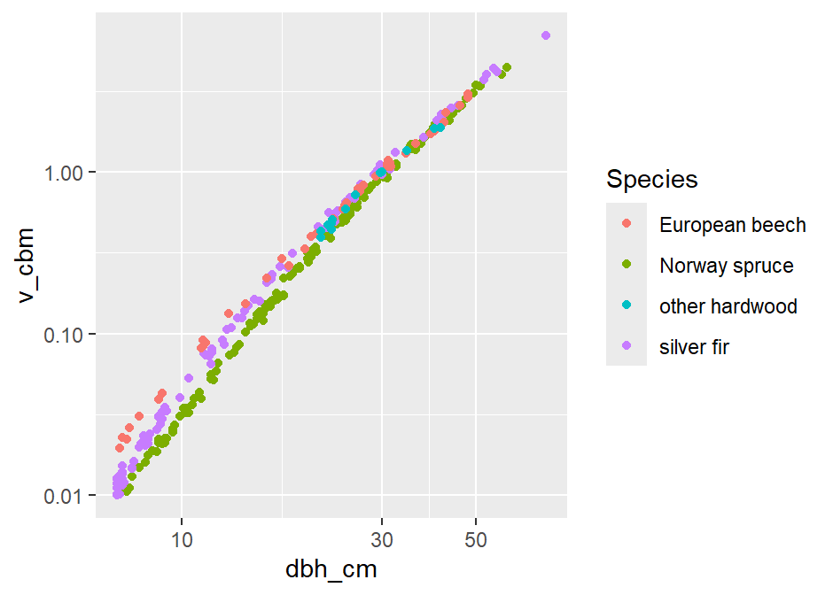

Stem volume over diameter by species in log-log display

```r
# Note: Using simply 'format(species_id)' below would use the current setting
# of the option fe_spec_lang
dat |>
  ggplot() +
  geom_point(aes(x = dbh_cm, y = v_cbm, col = format(species_id, "eng"))) +
  scale_color_discrete("Species") +
  scale_x_log10() +
  scale_y_log10()
```

## 4. Information for developers

There are two rather different developer tasks around species codings, and it helps to keep them apart:

1. **Maintaining the *data* of the codings** - adding a species to the master table, adding a code to an existing coding, fixing a name, or building a “short” aggregation coding. This is now entirely *CSV-driven*: a set of exported builder functions turns editable CSV files into the validated package data, steered by two workbench scripts in `data-raw/`. You edit CSV, you do not edit R code. Section 4.1 describes the layout, and Section 4.2 is a step-by-step recipe.
2. **Adding a genuinely *new* coding** - this additionally needs a new S3 (vctrs) class and the cast functions that connect it to all the other codings. That part still lives in R source files and is described in Section 4.3.

Finally, Section 4.4 repeats the standing warning never to touch `fe_species_helper_functions.R` without knowing *exactly* what you are doing.

Before we get into the details, note that all species codings inherit from the *vctrs_vctr* class, which is provided by the package [*vctrs*](https://vctrs.r-lib.org/index.html):

```r
fe_species_bavrn_state("30") |> class()
```

```
#> [1] "fe_species_bavrn_state" "vctrs_vctr"
```

```r
fe_species_ger_nfi_2012("20") |> class()
```

```
#> [1] "fe_species_ger_nfi_2012" "vctrs_vctr"
```

```r
fe_species_tum_wwk_long("87") |> class()
```

```
#> [1] "fe_species_tum_wwk_long" "vctrs_vctr"
```

```r
fe_species_tum_wwk_short("7") |> class()
```

```
#> [1] "fe_species_tum_wwk_short" "vctrs_vctr"
```

```r
fe_species_master("abies_004") |> class()
```

```
#> [1] "fe_species_master" "vctrs_vctr"
```

While this does not allow for building species_coding super- and subclasses, which would be an obvious feature for a system of species codings, it has a very convenient way of supporting casts between different classes. As this is a key requirement of our implementation, we decided to design a *vctrs* based solution.

### 4.1 The data behind the codings

All coding data is generated from editable CSV files by exported builder functions; the package data objects (`species_master_table`, `species_codings`, `species_cast_overrides`) are the *output*, never edited directly.

- **The master table** lives in `data-raw/species_master_table.csv` (exactly six columns: *genus*, *species_no*, *deciduous_conifer*, *name_sci*, *name_eng*, *name_ger*; one row per single species). `master_template_csv()` writes a fresh snapshot, and `master_table_from_csv()` reads it back with strict validation (unique keys, lower-case genus, three-digit *species_no*, no NAs).
- **Each coding** has its own CSV in `data-raw/codings/<coding>.csv`, in the *species-indexed + `parent_code`* format. There is one row per master species, plus extra declaration rows for group names. The key columns are:
  - *species_id* - the code assigned to that species. Leaving it empty means “this species is not covered by the coding”. Several species sharing one *species_id* form a group.
  - *parent_code* - the *species_id* of the coarser group that contains this code. This is what makes a coding *hierarchical*; a flat coding leaves *parent_code* empty throughout. The builder derives the *level* column from the `parent_code` chains.
  - *name_sci*, *name_eng*, *name_ger* - optional for a single-species code (then inherited from the master), but required for a group code (which has no master row).
  - *master_name_** and, for “short” codings, *agg_from_** are read-only reference columns to help while editing; the builder ignores them. Note there is **no** *is_tree* column to maintain: whether a code is a tree code is *derived* from its master link (a code with no master link, e.g. a “shrub” category, becomes a non-tree code automatically, with a message).
- `coding_template_from_master()` produces such a CSV (blank, or prefilled from an existing coding), and `coding_table_from_template()` turns the edited CSV into a validated coding table. It checks the *laminarity* invariant (codes are nested or disjoint, never partially overlapping), derives *level* and *is_tree*, and stores the rows in canonical order. For a “short” aggregation coding it additionally verifies, against the freshly built parent coding, that the coding is a valid coarsening (every parent group maps to exactly one short code). The parent/child pairs (`bavrn_state_short` ← `bavrn_state`, `tum_wwk_short` ← `tum_wwk_long`) are registered internally.
- **Cast overrides** are their own little CSV (`data-raw/codings/cast_overrides.csv`), built and validated by `cast_overrides_from_csv()` into the package object `species_cast_overrides` (see Section 3.3).

### 4.2 How to update the master table or an existing coding

These are the day-to-day data tasks, both driven by a workbench script in `data-raw/` that is meant to be run **manually, block by block** (not `source()`d in one go - the first block can overwrite a CSV).

**To add or change a species in the master table** (`data-raw/species_master_table.R`):

1. (Optional) run the snapshot step to refresh `data-raw/species_master_table.csv` from the installed table.
2. Edit the CSV: add or change rows (six columns, one row per species). A new species in an existing genus gets the next free *species_no*; a new genus starts at *001*.
3. Run `master_table_from_csv()`, inspect, then `usethis::use_data()` and reinstall the package so the coding builder sees the new master.

**To add a code to a coding, fix a name, or build a short coding** (`data-raw/species_codings.R`):

1. In the config block, set `coding_name` and `mode` (`"new"` starts a blank CSV from the master; `"edit"` prefills from the installed coding). The parent coding, if any, is resolved automatically.
2. Run the generate block to (re)write `data-raw/codings/<coding>.csv`.
3. Edit the CSV by hand following the rules in Section 4.1. For a short coding, use the *agg_from_** hint columns to keep all species of one parent group on the same code.
4. Run the build-and-validate block. It builds the coding from the CSV and reports its codes and any non-tree codes; an invalid laminarity or coarsening fails here with a clear message.
5. Run the full-rebuild block to regenerate the whole `species_codings` object (parents before children), then `usethis::use_data()` and reinstall. If the change affects a cast override, rerun `data-raw/cast_overrides.R` as well.
6. Run the tests with `devtools::test()` and a full `R CMD check`. Note that the `data-raw` CSVs are excluded from the built package (`.Rbuildignore`), so the test suite is deliberately written to work *without* them - run the real check, not just `test_dir()` against a loaded session.

### 4.3 Adding a brand-new coding

A genuinely new coding needs two things. Its *data* is built exactly as in Sections 4.1 and 4.2: add a new `data-raw/codings/<coding>.csv`, register the coding name in `data-raw/species_codings.R` (and, if the new coding is a “short” aggregation of an existing one, add a parent/child row to the internal aggregation registry). The builder takes care of *level*, *is_tree*, and non-tree codes automatically. What remains is the *code*: a vctrs S3 class plus the cast functions that connect the new coding to every other coding. The remaining steps cover that code side.

#### 4.3.1 Copy the R-source file of an existing coding and adapt it

Now, you must provide the functions in order to make your new coding workable. While this sounds difficult, it is actually really easy. Before we explain how to do that, be aware of the following naming convention:

*The S3 class covering your species coding must be named “fe_species_” followed by the name of your coding.*

In other words, if your new coding is named *john_doe_coding* (and that is also *exactly* what you called it in the tibble species codings), then your S3 class name must be *fe_species_john_doe_coding*.

First, copy the R source file of one of the implemented codings, and give it the name of your S3 class (in our example *fe_species_john_doe_coding.R*). Note, that the files with the existing implementation follow this naming convention. For this explanation, I assume you have copied and renamed the file *fe_species_tum_wwk_short.R*. You could now literally get an almost working implementation by automatic search for the term *fe_species_tum_wwk_short* and replace it with *fe_species_john_doe_coding*, however, if you must, do it function by function, not for the whole file in one go. Note, that you must also exchange the terms in the documentation above each function, not only in the R code itself. Important: you will also have to adjust the examples by using species codes which are actually covered by your coding. Otherwise, the examples will not work, and the package will not pass *R CMD check*.

From top to bottom of the file *fe_species_tum_wwk_short.R*, the functions to update are:

- the constructor *new_fe_species_tum_wwk_short*
- *is_fe_species_tum_wwk_short*
- the formatter *format.fe_species_tum_wwk_short*
- *summary.fe_species_tum_wwk_short*
- *vec_ptype_abbr.fe_species_tum_wwk_short*; here you should also replace the provided abbreviation for the coding name by one of your own (this abbreviation is printed e.g. as type information below the column head if your coding is a column of a tibble)
- *validate_fe_species_tum_wwk_short*
- *fe_species_tum_wwk_short*, the function users should use for constructing an instance of a species coding object
- *vec_proxy_order.fe_species_tum_wwk_short*; guarantees always the same order if species id’s are to be sorted. The order will not change, even if the option fe_spec_lang is changed
- Now comes a block of species type casting functions. Their names are built like .e.g *vec_cast.fe_species_tum_wwk_short.fe_species_ger_nfi_2012*, which means *vec_cast.fe_species_GOAL_CODING_NAME.fe_species_FROM_CODING_NAME*. These functions are very short, and some of them use the coding names internally. If you are qualified to work on this R package, you understand immediately, what to adapt. In general, in the function names, you must replace *tum_wwk_short* as the goal coding with *john_doe_coding*, In addition, you must copy one of the functions which casts between two species codings, and adapt it so that it casts from *tum_wwk_short* to *john_doe_coding*, i.e. name it *vec_cast.fe_species_john_doe_coding.fe_species_tum_wwk_short*, and make the obvious adaptions in the function’s body.
- *as_fe_species_tum_wwk_short* which is the actual functions users call for casts between codings

#### 4.3.2 Add a species coding cast function to each other coding

In the previous step, you have placed a *vec_cast* function that casts other codings into your new coding in the implementation of the new coding. Now, you have to add such a function that casts from your coding into another coding to the implementation of each other coding. In other words, the implementation of *fe_species_tum_wwk_short* requires a function called *vec_cast.fe_species_tum_wwk_short.fe_species_john_doe_coding*, and the implementation of *fe_species_ger_nfi_2012* requires a function *vec_cast.fe_species_ger_nfi_2023.fe_species_john_doe_coding*, and so on.

#### 4.3.3 Document the new coding

Clearly, when implementing your new species coding by editing an existing source file, you must adapt the existing documentation you find there to the new requirements. However, you must not forget to add your coding to the general documentation of species codings of the package. You find this in the file *data_species_codings.R* which is Roxygen2 code. Add a short description and examples in the same style as you find it for the other codings.

#### 4.3.4 Add your new coding to the automated tests for species codings

The package ForestElementsR comprises a suite of automated tests. You must add your now coding also there. You find the implementations of the tests in the subdirectory */tests/testhat/*; the files you need are called *test_species_coding_consistency*, and *test_species_coding_casts*. Several tests also iterate over *all* codings (e.g. for canonical row order, completeness, name uniqueness, and non-tree handling); a new coding is picked up there automatically once it is part of `species_codings`. See how the tests for the other codings are implemented, and follow these examples.

### 4.4 **Never** touch the source file *fe_species_helper_functions.R*

The functions in the source file *fe_species_helper_functions.R* were very carefully crafted, and they provide the common technical background for existing and future species codings implemented in the package *ForestElementsR*. If you fiddle around there without knowing *500% exactly* what you are doing, you will almost certainly goof it up.

## References

Riedel, T., P. Hennig, F. Kroiher, H. Polley, F. Schmitz, and Schwitzgebel F. 2017. *Die Dritte Bundeswaldinventur (BWI 2012). Inventur- Und Auswertungsmethoden*. Thuenen Institut fuer Waldoekosysteme.